# Evaluación 4

## Tarea 5

Get a polygons map of the lowest administrative unit possible.

Get a table of variables for those units. At least 3 numerical variables.

Preprocess both tables and get them ready for merging.

Do the merging, making the changes needed so that you keep the most columns.

```python
# En este caso, se consiguieron los mapas para los distritos, pero no se encontraron datos para cada distrito. En este sentido,
# solo quedó trabajar con las provincias. La República Democrática del Congo publicó el 2020 un anuario con muchos datos, pero
# estos casi completamente en función de las provincias. Se decidió trabajar con estos datos.
# fuente de los datos: https://ins.cd/wp-content/uploads/2022/06/ANNUAIRE-STATISTIQUE-2020.pdf
# Estos datos estaban en pdf, así que se tuvieron que copiar manualmente a un archivo de excel
```

```python
# Se definen las provincias a partir de una shape file
import os
import pandas as pd
import geopandas as gpd

Provincias_DRC = gpd.read_file(os.path.join("data","provincias_DRC","cod_admbnda_adm1_rgc_itos_20190911.shp"))
Provincias_DRC
```

|  | Shape_Leng | Shape_Area | ADM1_FR | ADM1_PCODE | ADM1_REF | ADM1ALT1FR | ADM1ALT2FR | ADM0_FR | ADM0_PCODE | date | validOn | validTo | geometry |
| --- | --- | --- | --- | --- | --- | --- | --- | --- | --- | --- | --- | --- | --- |
| 0 | 24.837413 | 12.097933 | Bas-Uele | CD52 | None | None | None | République démocratique du Congo (la) | CD | 2019-09-09 | 2019-09-11 | None | POLYGON ((25.55505 5.37646, 25.56033 5.37533, ... |
| 1 | 20.947731 | 8.291592 | Equateur | CD41 | None | None | None | République démocratique du Congo (la) | CD | 2019-09-09 | 2019-09-11 | None | POLYGON ((19.51188 2.02196, 19.60032 2.00518, ... |
| 2 | 29.557091 | 10.316791 | Haut-Katanga | CD71 | None | None | None | République démocratique du Congo (la) | CD | 2019-09-09 | 2019-09-11 | None | POLYGON ((28.54810 -7.62268, 28.56232 -7.63546... |
| 3 | 20.855157 | 8.952551 | Haut-Lomami | CD73 | None | None | None | République démocratique du Congo (la) | CD | 2019-09-09 | 2019-09-11 | None | POLYGON ((25.94890 -6.23409, 25.94897 -6.24754... |
| 4 | 21.679976 | 7.433290 | Haut-Uele | CD53 | None | None | None | République démocratique du Congo (la) | CD | 2019-09-09 | 2019-09-11 | None | POLYGON ((27.39413 5.09610, 27.41456 5.08784, ... |
| 5 | 17.849736 | 5.280520 | Ituri | CD54 | None | None | None | République démocratique du Congo (la) | CD | 2019-09-09 | 2019-09-11 | None | POLYGON ((30.78596 3.64700, 30.78596 3.62100, ... |
| 6 | 18.559369 | 7.887821 | Kasaï | CD92 | Kasai | None | None | République démocratique du Congo (la) | CD | 2019-09-09 | 2019-09-11 | None | POLYGON ((21.75535 -2.49128, 21.76883 -2.49800... |
| 7 | 14.745456 | 4.664225 | Kasaï-Central | CD91 | Kasai-Central | None | None | République démocratique du Congo (la) | CD | 2019-09-09 | 2019-09-11 | None | POLYGON ((22.91916 -4.52640, 22.94181 -4.52706... |
| 8 | 5.475921 | 0.833257 | Kasaï-Oriental | CD82 | Kasai-Oriental | None | None | République démocratique du Congo (la) | CD | 2019-09-09 | 2019-09-11 | None | POLYGON ((23.73511 -5.68923, 23.73781 -5.69317... |
| 9 | 5.604623 | 0.864438 | Kinshasa | CD10 | None | None | None | République démocratique du Congo (la) | CD | 2019-09-09 | 2019-09-11 | None | POLYGON ((15.95045 -3.93047, 15.95131 -3.93136... |
| 10 | 13.876726 | 4.402665 | Kongo-Central | CD20 | None | None | None | République démocratique du Congo (la) | CD | 2019-09-09 | 2019-09-11 | None | POLYGON ((14.41276 -4.31460, 14.41882 -4.32696... |
| 11 | 19.157190 | 7.352973 | Kwango | CD31 | None | None | None | République démocratique du Congo (la) | CD | 2019-09-09 | 2019-09-11 | None | POLYGON ((17.61221 -4.23314, 17.62396 -4.24320... |
| 12 | 16.848822 | 6.455370 | Kwilu | CD32 | None | None | None | République démocratique du Congo (la) | CD | 2019-09-09 | 2019-09-11 | None | POLYGON ((17.39747 -3.19806, 17.40001 -3.20150... |
| 13 | 16.305692 | 4.410003 | Lomami | CD81 | None | None | None | République démocratique du Congo (la) | CD | 2019-09-09 | 2019-09-11 | None | POLYGON ((25.00325 -4.86532, 25.00509 -4.86703... |
| 14 | 25.112956 | 10.038531 | Lualaba | CD72 | None | None | None | République démocratique du Congo (la) | CD | 2019-09-09 | 2019-09-11 | None | POLYGON ((21.96284 -7.69976, 21.97001 -7.70335... |
| 15 | 18.785376 | 10.450487 | Maï-Ndombe | CD33 | Mai-Ndombe | None | None | République démocratique du Congo (la) | CD | 2019-09-09 | 2019-09-11 | None | POLYGON ((19.15473 -0.82204, 19.16991 -0.85066... |
| 16 | 24.827430 | 10.383610 | Maniema | CD63 | None | None | None | République démocratique du Congo (la) | CD | 2019-09-09 | 2019-09-11 | None | POLYGON ((26.07762 -0.03658, 26.07949 -0.03686... |
| 17 | 17.154945 | 4.566610 | Mongala | CD44 | None | None | None | République démocratique du Congo (la) | CD | 2019-09-09 | 2019-09-11 | None | POLYGON ((22.71572 3.12765, 22.72612 3.11883, ... |
| 18 | 13.427228 | 4.790481 | Nord-Kivu | CD61 | None | None | None | République démocratique du Congo (la) | CD | 2019-09-09 | 2019-09-11 | None | POLYGON ((29.86257 0.95052, 29.86276 0.93075, ... |
| 19 | 14.722594 | 4.413101 | Nord-Ubangi | CD43 | None | None | None | République démocratique du Congo (la) | CD | 2019-09-09 | 2019-09-11 | None | POLYGON ((19.60200 5.13200, 19.61300 5.12800, ... |
| 20 | 17.636984 | 8.810696 | Sankuru | CD83 | None | None | None | République démocratique du Congo (la) | CD | 2019-09-09 | 2019-09-11 | None | POLYGON ((23.99545 -1.70136, 23.99908 -1.70323... |
| 21 | 14.423616 | 5.226450 | Sud-Kivu | CD62 | None | None | None | République démocratique du Congo (la) | CD | 2019-09-09 | 2019-09-11 | None | POLYGON ((29.05073 -1.58385, 29.05140 -1.58395... |
| 22 | 12.618229 | 4.234287 | Sud-Ubangi | CD42 | None | None | None | République démocratique du Congo (la) | CD | 2019-09-09 | 2019-09-11 | None | POLYGON ((19.07291 4.77567, 19.07509 4.77141, ... |
| 23 | 19.842214 | 10.846440 | Tanganyika | CD74 | None | None | None | République démocratique du Congo (la) | CD | 2019-09-09 | 2019-09-11 | None | POLYGON ((26.96836 -4.99952, 27.08852 -5.00293... |
| 24 | 26.602167 | 16.290309 | Tshopo | CD51 | None | None | None | République démocratique du Congo (la) | CD | 2019-09-09 | 2019-09-11 | None | POLYGON ((23.59908 2.20184, 23.59396 2.19113, ... |
| 25 | 23.911970 | 10.801180 | Tshuapa | CD45 | None | None | None | République démocratique du Congo (la) | CD | 2019-09-09 | 2019-09-11 | None | POLYGON ((22.12739 1.76262, 22.15742 1.76226, ... |

```python
# Ahora, se leen los datos que se obtuvieron
Estadisticas_DRC = pd.read_excel(os.path.join('data', 'Estad.xlsx'))
Estadisticas_DRC
```

|  | Provincia | Esperanza de vida | Años de escolarización | Número promedio de años de escolarización en adultos | Tasa de desempleo 2016 |
| --- | --- | --- | --- | --- | --- |
| 0 | Kinshasa | 64.6 | 13.7 | 11.2 | 11.4 |
| 1 | Kongo Central | 67.7 | 11.3 | 7.5 | 2.0 |
| 2 | Maï-Ndombe | 56.6 | 11.8 | 6.8 | 0.7 |
| 3 | Kwilu | 63.4 | 13.3 | 8.4 | 2.1 |
| 4 | Kwango | 51.5 | 10.7 | 5.2 | 0.4 |
| 5 | Equateur | 61.2 | 10.8 | 7.6 | 1.3 |
| 6 | Sud-Ubangi | 51.6 | 10.5 | 5.2 | 0.3 |
| 7 | Nord-Ubangi | 57.7 | 12.5 | 5.8 | 0.6 |
| 8 | Mongala | 56.0 | 8.4 | 5.4 | 0.1 |
| 9 | Tshuapa | 48.6 | 10.6 | 5.6 | 0.6 |
| 10 | Tshopo | 60.3 | 11.3 | 7.2 | 0.9 |
| 11 | Bas-Uele | 56.1 | 9.9 | 5.2 | 0.3 |
| 12 | Haut-Uele | 50.5 | 8.5 | 5.8 | 3.2 |
| 13 | Ituri | 58.7 | 6.8 | 3.5 | 1.7 |
| 14 | Nord Kivu | 59.5 | 11.2 | 8.4 | 8.2 |
| 15 | Sud Kivu | 62.5 | 9.2 | 7.6 | 2.7 |
| 16 | Maniema | 52.0 | 11.8 | 6.4 | 1.8 |
| 17 | Lualaba | 58.2 | 8.4 | 5.8 | 1.3 |
| 18 | Haut-Lomami | 53.9 | 8.5 | 5.8 | 2.3 |
| 19 | Tanganyika | 53.4 | 8.5 | 5.3 | 0.9 |
| 20 | Haut-Katanga | 56.7 | 12.4 | 10.0 | 11.1 |
| 21 | Kasaï Oriental | 50.6 | 9.5 | 6.9 | 2.0 |
| 22 | Sankuru | 51.0 | 11.9 | 6.8 | 2.1 |
| 23 | Lomami | 61.8 | 11.3 | 6.3 | 0.5 |
| 24 | Kasaï | 56.8 | 9.4 | 6.1 | 0.1 |
| 25 | Kasaï Central | 53.3 | 11.7 | 6.8 | 2.0 |

```python
# Hay datos irrelevantes, así que se procesan los data frame para que quede solo lo útil
```

```python
# La tabla con los datos está bastan bien, así que se deja así, pero igual se pueden cambiar los espacios de los nombres de las
# columnas
Estadisticas_DRC.columns = Estadisticas_DRC.columns.str.replace(' ', '_')
```

```python
# La gdf con los distritos sí tiene algunas columnas innecesarias

P_DRC = Provincias_DRC.loc[:,['ADM1_FR','geometry']]

#Finalmente, también se puede cambiar el nombre de la columna a provincias
P_DRC = P_DRC.rename(columns={'ADM1_FR': 'Provincia'})
P_DRC
```

|  | Provincia | geometry |
| --- | --- | --- |
| 0 | Bas-Uele | POLYGON ((25.55505 5.37646, 25.56033 5.37533, ... |
| 1 | Equateur | POLYGON ((19.51188 2.02196, 19.60032 2.00518, ... |
| 2 | Haut-Katanga | POLYGON ((28.54810 -7.62268, 28.56232 -7.63546... |
| 3 | Haut-Lomami | POLYGON ((25.94890 -6.23409, 25.94897 -6.24754... |
| 4 | Haut-Uele | POLYGON ((27.39413 5.09610, 27.41456 5.08784, ... |
| 5 | Ituri | POLYGON ((30.78596 3.64700, 30.78596 3.62100, ... |
| 6 | Kasaï | POLYGON ((21.75535 -2.49128, 21.76883 -2.49800... |
| 7 | Kasaï-Central | POLYGON ((22.91916 -4.52640, 22.94181 -4.52706... |
| 8 | Kasaï-Oriental | POLYGON ((23.73511 -5.68923, 23.73781 -5.69317... |
| 9 | Kinshasa | POLYGON ((15.95045 -3.93047, 15.95131 -3.93136... |
| 10 | Kongo-Central | POLYGON ((14.41276 -4.31460, 14.41882 -4.32696... |
| 11 | Kwango | POLYGON ((17.61221 -4.23314, 17.62396 -4.24320... |
| 12 | Kwilu | POLYGON ((17.39747 -3.19806, 17.40001 -3.20150... |
| 13 | Lomami | POLYGON ((25.00325 -4.86532, 25.00509 -4.86703... |
| 14 | Lualaba | POLYGON ((21.96284 -7.69976, 21.97001 -7.70335... |
| 15 | Maï-Ndombe | POLYGON ((19.15473 -0.82204, 19.16991 -0.85066... |
| 16 | Maniema | POLYGON ((26.07762 -0.03658, 26.07949 -0.03686... |
| 17 | Mongala | POLYGON ((22.71572 3.12765, 22.72612 3.11883, ... |
| 18 | Nord-Kivu | POLYGON ((29.86257 0.95052, 29.86276 0.93075, ... |
| 19 | Nord-Ubangi | POLYGON ((19.60200 5.13200, 19.61300 5.12800, ... |
| 20 | Sankuru | POLYGON ((23.99545 -1.70136, 23.99908 -1.70323... |
| 21 | Sud-Kivu | POLYGON ((29.05073 -1.58385, 29.05140 -1.58395... |
| 22 | Sud-Ubangi | POLYGON ((19.07291 4.77567, 19.07509 4.77141, ... |
| 23 | Tanganyika | POLYGON ((26.96836 -4.99952, 27.08852 -5.00293... |
| 24 | Tshopo | POLYGON ((23.59908 2.20184, 23.59396 2.19113, ... |
| 25 | Tshuapa | POLYGON ((22.12739 1.76262, 22.15742 1.76226, ... |

```python
# Ahora sí, se puede hacer el merge
```

```python
# Se procesan los nombres
# Primero, se eliminarán los espacios
P_DRC['Provincia'] = P_DRC.Provincia.str.replace(' ','_')
Estadisticas_DRC['Provincia'] = Estadisticas_DRC.Provincia.str.replace(' ','_')
# Después, los guiones medios
P_DRC['Provincia'] = P_DRC.Provincia.str.replace('-','_')
Estadisticas_DRC['Provincia'] = Estadisticas_DRC.Provincia.str.replace('-','_')

# Después, se strippearán las columnas
Estadisticas_DRC = Estadisticas_DRC.rename(columns=lambda x: x.strip())
P_DRC = P_DRC.rename(columns=lambda x: x.strip())

# Después, se le aplica directamente el unidecode, porque los nombres en francés tienen carácteres que pueden ser molestos
import unidecode

byePunctuation=lambda x: unidecode.unidecode(x)
P_DRC[['Provincia']]=P_DRC[['Provincia']].map(byePunctuation)
Estadisticas_DRC[['Provincia']]=Estadisticas_DRC[['Provincia']].map(byePunctuation)

# Tratamos directamente con el fuzzy merge
!pip install thefuzz
from thefuzz import process as fz
# Se crean sets con los  nombres
sP = set(P_DRC.Provincia)
sD = set(Estadisticas_DRC.Provincia)
# Ahora se calculan los coeficientes de igualdad
dMerge = [(f,fz.extractOne(f, sP)) for f in sorted(sD)]
dMerge, len(dMerge)
```

```
([('Bas_Uele', ('Bas_Uele', 100)),
  ('Equateur', ('Equateur', 100)),
  ('Haut_Katanga', ('Haut_Katanga', 100)),
  ('Haut_Lomami', ('Haut_Lomami', 100)),
  ('Haut_Uele', ('Haut_Uele', 100)),
  ('Ituri', ('Ituri', 100)),
  ('Kasai', ('Kasai', 100)),
  ('Kasai_Central', ('Kasai_Central', 100)),
  ('Kasai_Oriental', ('Kasai_Oriental', 100)),
  ('Kinshasa', ('Kinshasa', 100)),
  ('Kongo_Central', ('Kongo_Central', 100)),
  ('Kwango', ('Kwango', 100)),
  ('Kwilu', ('Kwilu', 100)),
  ('Lomami', ('Lomami', 100)),
  ('Lualaba', ('Lualaba', 100)),
  ('Mai_Ndombe', ('Mai_Ndombe', 100)),
  ('Maniema', ('Maniema', 100)),
  ('Mongala', ('Mongala', 100)),
  ('Nord_Kivu', ('Nord_Kivu', 100)),
  ('Nord_Ubangi', ('Nord_Ubangi', 100)),
  ('Sankuru', ('Sankuru', 100)),
  ('Sud_Kivu', ('Sud_Kivu', 100)),
  ('Sud_Ubangi', ('Sud_Ubangi', 100)),
  ('Tanganyika', ('Tanganyika', 100)),
  ('Tshopo', ('Tshopo', 100)),
  ('Tshuapa', ('Tshuapa', 100))],
 26)
```

```python
# Se mantuvo el número de filas?
len(dMerge) == len(P_DRC.Provincia)
```

```
True
```

```python
# Ahora sí se procede con el merge
DRC_Datos = Estadisticas_DRC.merge(P_DRC, how='left')
# El número de filas terminó siendo igual?
len(DRC_Datos.Provincia) == len(P_DRC.Provincia)
```

```
True
```

```python
# Parece que ya está mergeado de forma correcta, entonces
DRC_Datos
```

|  | Provincia | Esperanza_de_vida | Años_de_escolarización | Número_promedio_de_años_de_escolarización_en_adultos | Tasa_de_desempleo_2016 | geometry |
| --- | --- | --- | --- | --- | --- | --- |
| 0 | Kinshasa | 64.6 | 13.7 | 11.2 | 11.4 | POLYGON ((15.95045 -3.93047, 15.95131 -3.93136... |
| 1 | Kongo_Central | 67.7 | 11.3 | 7.5 | 2.0 | POLYGON ((14.41276 -4.31460, 14.41882 -4.32696... |
| 2 | Mai_Ndombe | 56.6 | 11.8 | 6.8 | 0.7 | POLYGON ((19.15473 -0.82204, 19.16991 -0.85066... |
| 3 | Kwilu | 63.4 | 13.3 | 8.4 | 2.1 | POLYGON ((17.39747 -3.19806, 17.40001 -3.20150... |
| 4 | Kwango | 51.5 | 10.7 | 5.2 | 0.4 | POLYGON ((17.61221 -4.23314, 17.62396 -4.24320... |
| 5 | Equateur | 61.2 | 10.8 | 7.6 | 1.3 | POLYGON ((19.51188 2.02196, 19.60032 2.00518, ... |
| 6 | Sud_Ubangi | 51.6 | 10.5 | 5.2 | 0.3 | POLYGON ((19.07291 4.77567, 19.07509 4.77141, ... |
| 7 | Nord_Ubangi | 57.7 | 12.5 | 5.8 | 0.6 | POLYGON ((19.60200 5.13200, 19.61300 5.12800, ... |
| 8 | Mongala | 56.0 | 8.4 | 5.4 | 0.1 | POLYGON ((22.71572 3.12765, 22.72612 3.11883, ... |
| 9 | Tshuapa | 48.6 | 10.6 | 5.6 | 0.6 | POLYGON ((22.12739 1.76262, 22.15742 1.76226, ... |
| 10 | Tshopo | 60.3 | 11.3 | 7.2 | 0.9 | POLYGON ((23.59908 2.20184, 23.59396 2.19113, ... |
| 11 | Bas_Uele | 56.1 | 9.9 | 5.2 | 0.3 | POLYGON ((25.55505 5.37646, 25.56033 5.37533, ... |
| 12 | Haut_Uele | 50.5 | 8.5 | 5.8 | 3.2 | POLYGON ((27.39413 5.09610, 27.41456 5.08784, ... |
| 13 | Ituri | 58.7 | 6.8 | 3.5 | 1.7 | POLYGON ((30.78596 3.64700, 30.78596 3.62100, ... |
| 14 | Nord_Kivu | 59.5 | 11.2 | 8.4 | 8.2 | POLYGON ((29.86257 0.95052, 29.86276 0.93075, ... |
| 15 | Sud_Kivu | 62.5 | 9.2 | 7.6 | 2.7 | POLYGON ((29.05073 -1.58385, 29.05140 -1.58395... |
| 16 | Maniema | 52.0 | 11.8 | 6.4 | 1.8 | POLYGON ((26.07762 -0.03658, 26.07949 -0.03686... |
| 17 | Lualaba | 58.2 | 8.4 | 5.8 | 1.3 | POLYGON ((21.96284 -7.69976, 21.97001 -7.70335... |
| 18 | Haut_Lomami | 53.9 | 8.5 | 5.8 | 2.3 | POLYGON ((25.94890 -6.23409, 25.94897 -6.24754... |
| 19 | Tanganyika | 53.4 | 8.5 | 5.3 | 0.9 | POLYGON ((26.96836 -4.99952, 27.08852 -5.00293... |
| 20 | Haut_Katanga | 56.7 | 12.4 | 10.0 | 11.1 | POLYGON ((28.54810 -7.62268, 28.56232 -7.63546... |
| 21 | Kasai_Oriental | 50.6 | 9.5 | 6.9 | 2.0 | POLYGON ((23.73511 -5.68923, 23.73781 -5.69317... |
| 22 | Sankuru | 51.0 | 11.9 | 6.8 | 2.1 | POLYGON ((23.99545 -1.70136, 23.99908 -1.70323... |
| 23 | Lomami | 61.8 | 11.3 | 6.3 | 0.5 | POLYGON ((25.00325 -4.86532, 25.00509 -4.86703... |
| 24 | Kasai | 56.8 | 9.4 | 6.1 | 0.1 | POLYGON ((21.75535 -2.49128, 21.76883 -2.49800... |
| 25 | Kasai_Central | 53.3 | 11.7 | 6.8 | 2.0 | POLYGON ((22.91916 -4.52640, 22.94181 -4.52706... |

```python
# Finalmente, nos aseguramos de que el resultado sea un gdf con el crc deseado
DRC_Datos= gpd.GeoDataFrame(DRC_Datos, crs = 4326)
DRC_Datos = DRC_Datos.to_crs(32734)
type(DRC_Datos)
```

```
geopandas.geodataframe.GeoDataFrame
```

```python
#Todo bien!
```

## Tarea 6

Choose a numeric variable from your merged data.

Decide which is the best classification scheme for that variable . Make a map for the best schem e. Make a histogram for the best scheme.

```python
# Primero, hay que probar varios sistemas para los intervalos, según el método que se enseñó en clase
# El seaborn no parece ser necesario, pero igual lo estoy instalando en caso pueda faltar algo más adelante
!pip install seaborn
import seaborn as sea
!pip install numba
import mapclassify
import numpy as np

np.random.seed(1234)
```

```python
# Se decide hacer 6 intervalos

K=6
Variable=DRC_Datos['Esperanza_de_vida']
ei6 = mapclassify.EqualInterval(Variable, k=K)
msd = mapclassify.StdMean(Variable)
q6=mapclassify.Quantiles(Variable,k=K)
mb6 = mapclassify.MaximumBreaks(Variable, k=K)
ht = mapclassify.HeadTailBreaks(Variable)
fj6 = mapclassify.FisherJenks(Variable, k=K)
jc6 = mapclassify.JenksCaspall(Variable, k=K)
mp6 = mapclassify.MaxP(Variable, k=K)
```

```python
# Para comparar a las clasificaciones, se calcula la desviación absoluta media del parámetro (ADCM)
Clase = q6, ei6,msd, ht, mb6, fj6, jc6, mp6
Fits = np.array([ c.adcm for c in Clase])
ADCM = pd.DataFrame(Fits)
ADCM['Clasificador'] = [c.name for c in Clase]

ADCM.rename(columns = {0:'ADCM'},inplace=True)

ADCM
```

|  | ADCM | Clasificador |
| --- | --- | --- |
| 0 | 23.0 | Quantiles |
| 1 | 18.2 | EqualInterval |
| 2 | 39.2 | StdMean |
| 3 | 35.7 | HeadTailBreaks |
| 4 | 32.9 | MaximumBreaks |
| 5 | 16.4 | FisherJenks |
| 6 | 20.3 | JenksCaspall |
| 7 | 24.1 | MaxP |

```python
# El ADCM del FisherJenks es el mínimo, así que se elige
```

```python
# Se crea una columna con esto valores para el gdf
DRC_Datos['EVida_FJ'] = fj6.yb
DRC_Datos
```

|  | Provincia | Esperanza_de_vida | Años_de_escolarización | Número_promedio_de_años_de_escolarización_en_adultos | Tasa_de_desempleo_2016 | geometry | EVida_FJ |
| --- | --- | --- | --- | --- | --- | --- | --- |
| 0 | Kinshasa | 64.6 | 13.7 | 11.2 | 11.4 | POLYGON ((-61300.711 9563859.412, -61204.548 9... | 4 |
| 1 | Kongo_Central | 67.7 | 11.3 | 7.5 | 2.0 | POLYGON ((-232539.039 9519919.345, -231850.343... | 5 |
| 2 | Mai_Ndombe | 56.6 | 11.8 | 6.8 | 0.7 | POLYGON ((294652.660 9909092.711, 296344.727 9... | 2 |
| 3 | Kwilu | 63.4 | 13.3 | 8.4 | 2.1 | POLYGON ((99484.640 9645811.454, 99768.716 964... | 4 |
| 4 | Kwango | 51.5 | 10.7 | 5.2 | 0.4 | POLYGON ((123826.716 9531280.885, 125138.101 9... | 0 |
| 5 | Equateur | 61.2 | 10.8 | 7.6 | 1.3 | POLYGON ((334493.735 10223563.902, 344329.518 ... | 4 |
| 6 | Sud_Ubangi | 51.6 | 10.5 | 5.2 | 0.3 | POLYGON ((286262.108 10528166.452, 286502.978 ... | 0 |
| 7 | Nord_Ubangi | 57.7 | 12.5 | 5.8 | 0.6 | POLYGON ((345041.829 10567424.526, 346260.396 ... | 2 |
| 8 | Mongala | 56.0 | 8.4 | 5.4 | 0.1 | POLYGON ((690663.230 10345858.087, 691820.745 ... | 2 |
| 9 | Tshuapa | 48.6 | 10.6 | 5.6 | 0.6 | POLYGON ((625399.442 10194860.722, 628739.643 ... | 0 |
| 10 | Tshopo | 60.3 | 11.3 | 7.2 | 0.9 | POLYGON ((789099.495 10243623.087, 788531.953 ... | 3 |
| 11 | Bas_Uele | 56.1 | 9.9 | 5.2 | 0.3 | POLYGON ((1005174.139 10596162.746, 1005762.21... | 2 |
| 12 | Haut_Uele | 50.5 | 8.5 | 5.8 | 3.2 | POLYGON ((1210174.926 10566818.663, 1212463.04... | 0 |
| 13 | Ituri | 58.7 | 6.8 | 3.5 | 1.7 | POLYGON ((1592056.253 10409084.904, 1592088.13... | 3 |
| 14 | Nord_Kivu | 59.5 | 11.2 | 8.4 | 8.2 | POLYGON ((1490027.538 10106338.872, 1490054.48... | 3 |
| 15 | Sud_Kivu | 62.5 | 9.2 | 7.6 | 2.7 | POLYGON ((1398481.224 9823182.865, 1398556.320... | 4 |
| 16 | Maniema | 52.0 | 11.8 | 6.4 | 1.8 | POLYGON ((1065757.855 9995940.759, 1065966.797... | 0 |
| 17 | Lualaba | 58.2 | 8.4 | 5.8 | 1.3 | POLYGON ((606184.942 9148773.880, 606975.615 9... | 3 |
| 18 | Haut_Lomami | 53.9 | 8.5 | 5.8 | 2.3 | POLYGON ((1048123.755 9308342.789, 1048117.583... | 1 |
| 19 | Tanganyika | 53.4 | 8.5 | 5.3 | 0.9 | POLYGON ((1162808.839 9444371.953, 1176198.591... | 1 |
| 20 | Haut_Katanga | 56.7 | 12.4 | 10.0 | 11.1 | POLYGON ((1334890.197 9150087.744, 1336446.305... | 2 |
| 21 | Kasai_Oriental | 50.6 | 9.5 | 6.9 | 2.0 | POLYGON ((802973.914 9370431.302, 803270.895 9... | 0 |
| 22 | Sankuru | 51.0 | 11.9 | 6.8 | 2.1 | POLYGON ((833324.967 9811688.669, 833729.282 9... | 0 |
| 23 | Lomami | 61.8 | 11.3 | 6.3 | 0.5 | POLYGON ((944226.038 9460904.706, 944429.544 9... | 4 |
| 24 | Kasai | 56.8 | 9.4 | 6.1 | 0.1 | POLYGON ((583975.122 9724613.012, 585473.061 9... | 2 |
| 25 | Kasai_Central | 53.3 | 11.7 | 6.8 | 2.0 | POLYGON ((712932.929 9499404.379, 715446.097 9... | 1 |

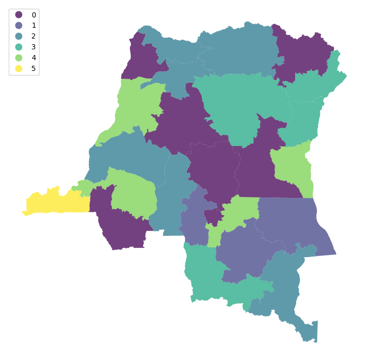

```python
# Ahora, se grafica el mapa con las clasificaciones
import matplotlib.pyplot as plt
f, ax = plt.subplots(1, figsize=(9, 9))
DRC_Datos.plot(column='EVida_FJ',
        cmap='viridis',
        categorical=True,
        edgecolor='white',
        linewidth=0.,
        alpha=0.75,
        legend=True,
        legend_kwds=dict(loc=2),
        ax=ax
       )

ax.set_axis_off()
```

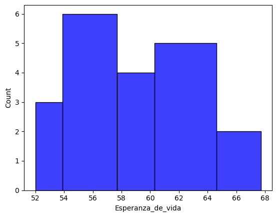

```python
# Finalmente, se hace el histograma
fj6_bins=list(fj6.bins)
sea.histplot(DRC_Datos.Esperanza_de_vida, bins=fj6_bins, color='blue')
```

## Tarea 7

Compute the neighbors of the capital of your country. Plot the results for each of the options.

```python
# Ahora, como no se necesitan los datos numéricos que no se pudieron conseguir para los distritos,
# sí se puede trabajar con estos
Distritos_DRC = gpd.read_file(os.path.join("data","provincias_DRC","cod_admbnda_adm2_rgc_20190911.shp"))
Distritos_DRCs= gpd.GeoDataFrame(Distritos_DRC, crs = 4326)
Distritos_DRC = Distritos_DRC.to_crs(32734)

# Después, se procesan un poco los nombres de la columna de los distritos, para no tener problemas luego
Distritos_DRC['ADM2_FR'] = Distritos_DRC.ADM2_FR.str.replace(' ','_')
Distritos_DRC = Distritos_DRC.rename(columns=lambda x: x.strip())
import unidecode
byePunctuation=lambda x: unidecode.unidecode(x)
Distritos_DRC[['ADM2_FR']]=Distritos_DRC[['ADM2_FR']].map(byePunctuation)

# Finalmente, se revisa si es un gdf
type(Distritos_DRC)
```

```
geopandas.geodataframe.GeoDataFrame
```

```python
# Se instala el libsypal y se invoca a las funciones Queen, Rook y King (las tres opciones posibles para el cálculo)
!pip install libpysal
from libpysal.weights import Queen, Rook, KNN
```

```python
# Ahora, se averigua cuál es la fila que contiene a la capital
Distritos_DRC.ADM2_FR.str.contains('Kinshasa').sort_values()
```

```
0      False
121    False
122    False
123    False
124    False
       ...
67     False
68     False
59     False
188    False
97      True
Name: ADM2_FR, Length: 189, dtype: bool
```

```python
# Es la 97!
Distritos_DRC.ADM2_FR[97]
```

```
'Kinshasa'
```

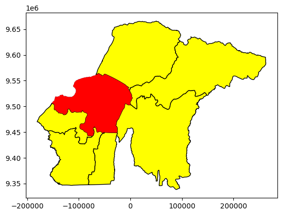

```python
# Primero el rook, con los vecinos en amarillo y Kinshasa (capital) en rojo
CDR_rook = Rook.from_dataframe(Distritos_DRC,use_index=False)
# Se grafica
base=Distritos_DRC[Distritos_DRC.ADM2_FR=="Kinshasa"].plot()
Distritos_DRC.iloc[CDR_rook.neighbors[97] ,].plot(ax=base,facecolor="yellow",edgecolor='k')
Distritos_DRC.iloc[[97],:].plot(ax=base,facecolor="red")
```

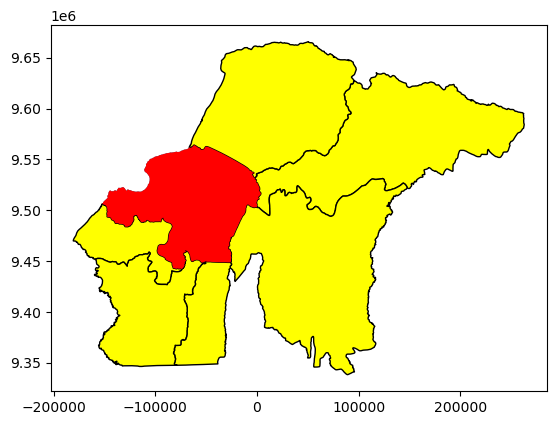

```python
# Ahora con queen
CDR_queen = Queen.from_dataframe(Distritos_DRC,use_index=False)
base=Distritos_DRC[Distritos_DRC.ADM2_FR=="Kinshasa"].plot()
Distritos_DRC.iloc[CDR_queen.neighbors[97] ,].plot(ax=base,facecolor="yellow",edgecolor='k')
Distritos_DRC.iloc[[97],:].plot(ax=base,facecolor="red")
```

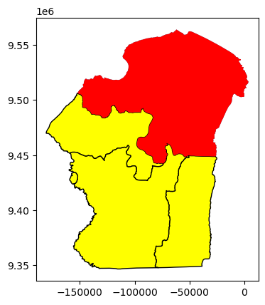

```python
# Finalmente, con king
CDR_knn = KNN.from_dataframe(Distritos_DRC, k=4)
base=Distritos_DRC[Distritos_DRC.ADM2_FR=="Kinshasa"].plot()
Distritos_DRC.iloc[CDR_knn.neighbors[97] ,].plot(ax=base,facecolor="yellow",edgecolor='k')
Distritos_DRC.iloc[[97],:].plot(ax=base,facecolor="red")
```

```python
# Se observa que para rook y queen es igual, mientras que para king se pierden algunos distritos. Esto se debe a que para knn
# se fija un número de vecinos y se elige a los 'k' más cercanos. Curiosamente, en knn se tuvo a una pequeña provincia extra en vez de las
# que estaban inmediatamente cerca.
# Parece que para este caso, queen y rook son más fiables
# Como dato final, al norte de Kinshasa está el Rio Congo y su frontera con la República del Congo (No confundir con la República Democrática del Congo)
# por lo que es normal que no haya provincias vecinas hacia el norte
```